# Epi Machine Learning Assignment 4

Sydney Ng (uni: sn2863)

Due February 9, 2021 by 5:30 PM

**Cleaning and visualizing the data**

```r
# data cleaning
dat <- read_csv("./class4_p1.csv") %>%
  janitor::clean_names() %>%
   mutate(id = as.character(x1),
          hypertension = as.factor(case_when(chronic1 == 2 ~ "No",
                                             chronic1 == 1 ~ "Yes")),
         diabetes = as.factor(case_when(chronic3 == 2 ~ "No",
                                        chronic3 == 1 ~ "Yes")),
         asthma = as.factor(case_when(chronic4 == 2 ~ "No",
                                      chronic4 == 1 ~ "Yes")),
         tobacco = factor(case_when(tobacco1 == 3 ~ "Never",
                                       tobacco1 == 2 ~ "Some days",
                                       tobacco1 == 1 ~ "Most days (or all days)"),
                          levels = c("Never", "Some days", "Most days (or all days)", NA)),
         alcohol = factor(case_when(alcohol1 == 3 ~ "Never",
                                    alcohol1 == 2 ~ "Some days",
                                    alcohol1 == 1 ~ "Most days (or all days)"),
                          levels = c("Never", "Some days", "Most days (or all days)", NA)),
         sex = as.factor(case_when(dem3 == 1 ~ "Male", dem3 == 2 ~ "Female")),
                         # 1 = males are reference; 2 = females -- completely filled feature
         ethnicity = factor(case_when(dem4 == 2 ~ "Not Hispanic or Latino",
                                     dem4 == 1 ~ "Hispanic or Latino"),
                           levels = c("Not Hispanic or Latino", "Hispanic or Latino", NA)),
         born_US = factor(case_when(dem8 == 1 ~ "USA",
                                    dem8 == 2 ~ "Outside USA"),
                                    levels = c("USA", "Outside USA", NA)),
         activity = factor(case_when(habits5 == 4 ~ "Not active at all",
                                    habits5 == 3 ~ "Not very active",
                                    habits5 == 2 ~ "Somwhat active",
                                    habits5 == 1 ~ "Very active"),
                          levels = c("Not active at all","Not very active",
                                     "Somwhat active","Very active",NA)),
         agegroup = factor(case_when(agegroup == 1 ~ "18-24",
                                     agegroup == 2 ~ "25-44",
                                     agegroup == 3 ~ "45-64",
                                     agegroup == 4 ~ "65+"),
                           levels = c("18-24", "25-44", "45-64", "65+")),
         povertygroup = as.factor(case_when(povertygroup == 1 ~ "<100%",
                                            povertygroup == 2 ~ "100-199%",
                                            povertygroup == 3 ~ "200-399%",
                                            povertygroup == 4 ~ "400-599%",
                                            povertygroup == 5 ~ "600% +"))) %>%
  select(-c(chronic1, chronic3, chronic4, tobacco1, alcohol1,
            habits5, habits7, dem3, dem4, dem8, x1)) %>%
  na.omit(healthydays)

# our outcome of interest is healthydays -- the 744 NA's are removed, n = 3067
# habits7 for rating diet on a likert scale was taken out because the data were 91.5% NA's
# gpaq11days: During the last 7 days, on how many days did you walk to get to and from places?
# gpaq8totmin: Minutes of total physical activity on home chores on an average day
```

**Splitting the data into training and testing (70/30).**

```r
set.seed(1234)

train.indices <-
  createDataPartition(y = dat$healthydays, p=0.7, list=FALSE) %>%
  as.vector()

training <- dat[train.indices,]
testing <- dat[-train.indices,]
```

# Part I

**Implementing a Simple Prediction Pipeline**

### Problem 1.

Fit two prediction models using different subsets of the features in the training data. Features can overlap in the two models, but the feature sets should not be exactly the same across models. Clearly state which features were used in the two models.

```r
model.1 <-
  glm(healthydays ~ bmi + tobacco + sex + ethnicity + gpaq8totmin + povertygroup + activity,
      family = poisson, data = training)
model.1 %>% broom::tidy()
```

```
## # A tibble: 14 x 5
##    term                             estimate std.error statistic  p.value
##    <chr>                               <dbl>     <dbl>     <dbl>    <dbl>
##  1 (Intercept)                     2.97      0.0324       91.9   0.
##  2 bmi                            -0.00194   0.000719     -2.70  6.88e- 3
##  3 tobaccoSome days               -0.0704    0.0195       -3.61  3.01e- 4
##  4 tobaccoMost days (or all days) -0.0191    0.0141       -1.35  1.76e- 1
##  5 sexMale                        -0.00584   0.00864      -0.676 4.99e- 1
##  6 ethnicityHispanic or Latino    -0.0173    0.0107       -1.62  1.06e- 1
##  7 gpaq8totmin                    -0.0000142 0.0000474    -0.299 7.65e- 1
##  8 povertygroup100-199%            0.0310    0.0141        2.20  2.77e- 2
##  9 povertygroup200-399%            0.111     0.0137        8.07  7.04e-16
## 10 povertygroup400-599%            0.108     0.0143        7.56  4.17e-14
## 11 povertygroup600% +              0.123     0.0135        9.11  8.35e-20
## 12 activityNot very active         0.216     0.0238        9.09  1.01e-19
## 13 activitySomwhat active          0.311     0.0222       14.0   2.36e-44
## 14 activityVery active             0.327     0.0228       14.3   1.55e-46
```

```r
model.2 <-
  glm(healthydays ~ bmi + povertygroup + ethnicity + sex, family=poisson, data=training)
model.2 %>% broom::tidy()
```

```
## # A tibble: 8 x 5
##   term                        estimate std.error statistic  p.value
##   <chr>                          <dbl>     <dbl>     <dbl>    <dbl>
## 1 (Intercept)                  3.30     0.0223     148.    0.
## 2 bmi                         -0.00401  0.000704    -5.69  1.24e- 8
## 3 povertygroup100-199%         0.0281   0.0141       2.00  4.56e- 2
## 4 povertygroup200-399%         0.116    0.0137       8.48  2.28e-17
## 5 povertygroup400-599%         0.114    0.0142       8.01  1.15e-15
## 6 povertygroup600% +           0.136    0.0134      10.2   2.70e-24
## 7 ethnicityHispanic or Latino -0.0156   0.0107      -1.46  1.43e- 1
## 8 sexMale                     -0.00385  0.00859     -0.448 6.54e- 1
```

### Problem 2.

Applying both models within the test data and determine which model is the preferred prediction model using the appropriate evaluation metric.

```r
fitted.results1 <- predict(model.1, testing, type='response')
fitted.results2 <- predict(model.2, testing, type='response')

rmse_model1 <- sqrt(mean((testing$healthydays - fitted.results1)^2, na.rm=TRUE))
rmse_model2 <- sqrt(mean((testing$healthydays - fitted.results2)^2, na.rm=TRUE))
```

I am evaluating my models using the root mean-squared error (RMSE).

The RMSE for model 1 is less than that of model 2, hence **model 1 is the preferred prediction model**.

### Problem 3.

The implementation of my final model would be useful in a public health setting if we wanted to predict the number of days in a month an individual reports good health, with basic health information including BMI and minutes of activity, demographic information including sex, ethnicity, and poverty level, as well as lifestyle information including smoking status.

# Part II

### Problem 4.

```r
data("USArrests")

# Checking means and SDs to determine if scaling is necessary
colMeans(USArrests, na.rm=TRUE)
```

```
##   Murder  Assault UrbanPop     Rape
##    7.788  170.760   65.540   21.232
```

```r
apply(USArrests, 2, sd, na.rm=TRUE)
```

```
##    Murder   Assault  UrbanPop      Rape
##  4.355510 83.337661 14.474763  9.366385
```

Looking at the means and standard deviations of the features in the `USArrests` dataset, we should standardize because the values vary by quite a lot. If we do not, it is likely Assault will dominate when we create clusters due to its large magnitude.

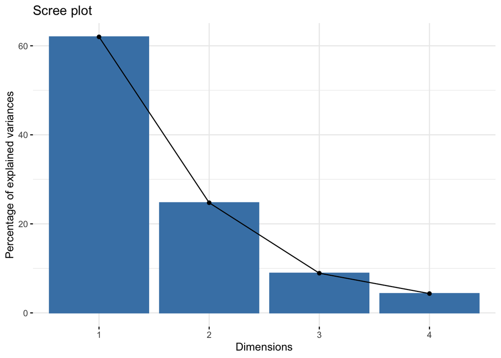

```r
arrests_pca <- prcomp( ~., data = USArrests, center=TRUE, scale=TRUE, na.action=na.omit)

#Generates scree plot
fviz_eig(arrests_pca)
```

```r
summary(arrests_pca)
```

```
## Importance of components:
##                           PC1    PC2     PC3     PC4
## Standard deviation     1.5749 0.9949 0.59713 0.41645
## Proportion of Variance 0.6201 0.2474 0.08914 0.04336
## Cumulative Proportion  0.6201 0.8675 0.95664 1.00000
```

```r
  # we are more concerned with the cumulative proportion...
  # or can look at standard deviation -- cut off at 1, which is at PC2?

# Identify how features loaded on the different components
arrests_pca$rotation
```

```
##                 PC1        PC2        PC3         PC4
## Murder   -0.5358995  0.4181809 -0.3412327  0.64922780
## Assault  -0.5831836  0.1879856 -0.2681484 -0.74340748
## UrbanPop -0.2781909 -0.8728062 -0.3780158  0.13387773
## Rape     -0.5434321 -0.1673186  0.8177779  0.08902432
```

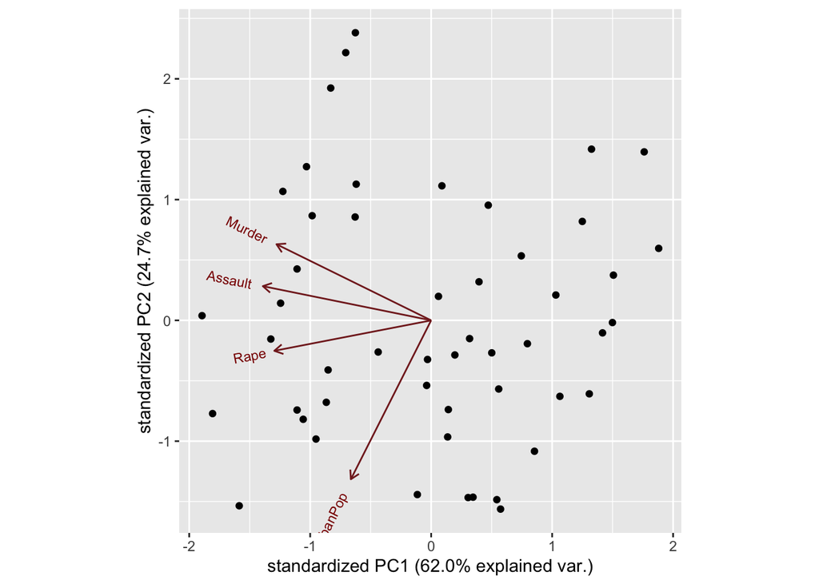

```r
ggbiplot(arrests_pca)
```

After looking at the scree plot and the results of the principal components analysis, it seems like the best number of principal components is 2. The resulting data from the PCA with the scaling is `arrests_pca$x`.

**Hierarchical clustering using complete linkage**

```r
# Create Dissimilarity matrix
diss.matrix <- dist(arrests_pca$x, method = "euclidean")

gap_stat <- clusGap(arrests_pca$x, FUN = hcut, hc_method="complete", K.max = 10, B = 50)
fviz_gap_stat(gap_stat)

# Hierarchical clustering using Complete Linkage
clusters.hcut <- hcut(arrests_pca$x, k=2, hc_func="hclust", hc_method="complete", hc_metric="euclidian")
clusters.hcut$size
```

```
## [1] 19 31
```

```
## # A tibble: 2 x 5
##   cluster Murder Assault UrbanPop  Rape
##     <int>  <dbl>   <dbl>    <dbl> <dbl>
## 1       1  12.3     259.     68.3  29.2
## 2       2   5.00    116.     63.8  16.3
```

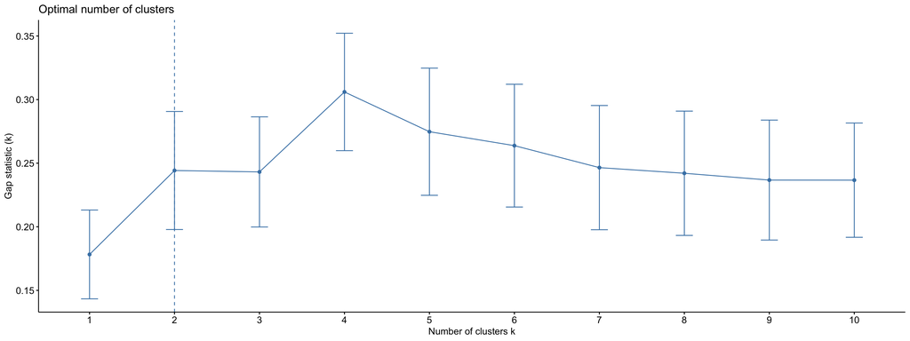

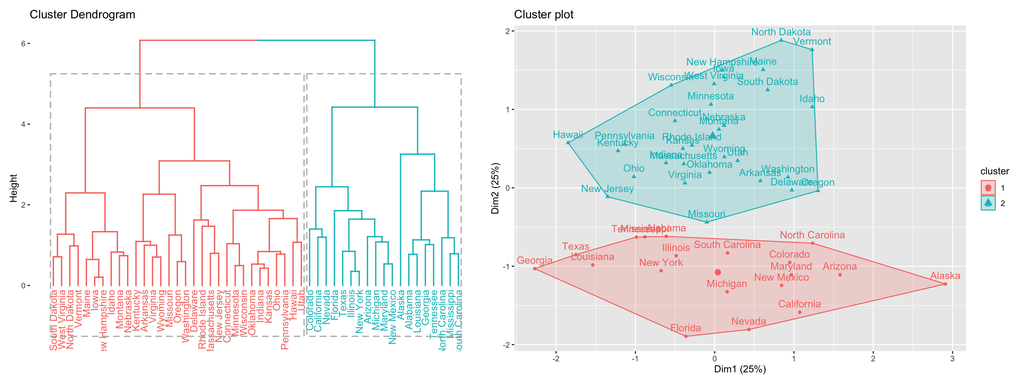

```r
fviz_dend(clusters.hcut, rect=TRUE) + fviz_cluster(clusters.hcut)

input.feature.vals <-
  bind_cols(USArrests, cluster=clusters.hcut$cluster)

input.feature.vals %>%
  group_by(cluster) %>%
  summarise_all(mean)
```

The optimal number of clusters in this example using complete linkage is 2.

**Hierarchical clustering using average linkage**

```r
gap_stat_avg <- clusGap(arrests_pca$x, FUN = hcut, hc_method="average", K.max = 10, B = 50)
fviz_gap_stat(gap_stat_avg)

# Hierarchical clustering using Complete Linkage
clusters.hcutavg <- hcut(arrests_pca$x, k=2, hc_func="hclust", hc_method="average", hc_metric="euclidian")
clusters.hcutavg$size
```

```
## [1] 20 30
```

```
## # A tibble: 2 x 5
##   cluster Murder Assault UrbanPop  Rape
##     <int>  <dbl>   <dbl>    <dbl> <dbl>
## 1       1  12.2     255.     68.4  29.2
## 2       2   4.87    114.     63.6  15.9
```

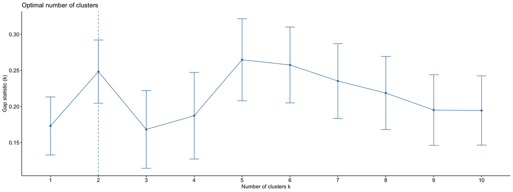

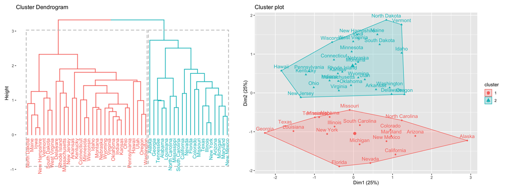

```r
fviz_dend(clusters.hcutavg, rect=TRUE) + fviz_cluster(clusters.hcutavg)

input.feature.vals.avg <-
  bind_cols(USArrests, cluster=clusters.hcutavg$cluster)

input.feature.vals.avg %>%
  group_by(cluster) %>%
  summarise_all(mean)
```

The optimal number of clusters in this example using average linkage is 2.

- Cluster 1 has an average of 68.4% urban population, 12.2 murder arrests, 255 assault arrests, and 29.2 rape arrests (per 100,000).
- Cluster 2 has an average of 63.6% urban population, 4.87 murder arrests, 114 assault arrests, and 15.9 rape arrests (per 100,000).
- It seems that the difference between these two clusters is that the states in Cluster 2 have less serious crime arrests in general. The percent urban population for the two clusters seems similar.

Overall, when comparing these two linkages (complete versus average), the results seem very similar. Both types of linkages yield 2 clusters as the optimal number, and the difference between the two clusters seems to be that Cluster 1 has more serious crime arrests in all three types than Cluster 2. Furthermore, Cluster 1 has a slightly larger proportion of urban residents than Cluster 2 using both linkage methods.

### Problem 5.

A research question that can be addressed using these two newly identified clusters is: **Do clusters of states’ serious arrests rates predict obesity rates in the United States?**

An ethical consideration one should review before using these clusters to answer this research question is what these averages represent. In particular, it would be important to review the racial make-up of these arrests and the urban population. It is likely that the BIPOC population faces greater health disparities than the white population, on top of innocent black people being 7 times more likely to be convicted of murder and 3.5 times more likely to be convicted of sexual assault than their white counterparts (source: https://www.vox.com/policy-and-politics/2017/3/7/14834454/exoneration-innocence-prison-racism).

Another scientific consideration to review would be how the data were collected and aggregated. Pretending that these data are from 2020, it is easier to double-check these numbers with state-level data to perform some sort of data-audit. This will ensure that the aggregated state arrests for these serious crimes are accurate.